# Machine Learning Modelling

```python
# Load and Inspect Data

# Import necessary library
import pandas as pd

# Define file paths
train_path = r"C:\Users\user\Documents\mldata_0003260938.csv"
test_path = r"C:\Users\user\Documents\mldata_0003260938.TEST_FEATURES.csv"

# Load the CSV files
train_df = pd.read_csv(train_path)
test_df = pd.read_csv(test_path)

# Inspect shapes
print("Training Data Shape:", train_df.shape)
print("Test Data Shape:", test_df.shape)

# View column names
print("\nTraining Columns:\n", train_df.columns.tolist())
print("\nTest Columns:\n", test_df.columns.tolist())

# View first few rows
print("\nTraining Data Preview:")
print(train_df.head())

print("\nTest Data Preview:")
print(test_df.head())

# View data types and null values
print("\nTraining Data Info:")
print(train_df.info())

print("\nTest Data Info:")
print(test_df.info())
```

```
Training Data Shape: (1300, 27)
Test Data Shape: (1300, 26)

Training Columns:
 ['Unnamed: 0', 'label', 'feature_1', 'feature_2', 'feature_3', 'feature_4', 'feature_5', 'feature_6', 'feature_7', 'feature_8', 'feature_9', 'feature_10', 'feature_11', 'feature_12', 'feature_13', 'feature_14', 'feature_15', 'feature_16', 'feature_17', 'feature_18', 'feature_19', 'feature_20', 'fea…

Test Columns:
 ['id', 'feature_1', 'feature_2', 'feature_3', 'feature_4', 'feature_5', 'feature_6', 'feature_7', 'feature_8', 'feature_9', 'feature_10', 'feature_11', 'feature_12', 'feature_13', 'feature_14', 'feature_15', 'feature_16', 'feature_17', 'feature_18', 'feature_19', 'feature_20', 'feature_21', 'featur…

Training Data Preview:
   Unnamed: 0  label  feature_1  feature_2  feature_3  feature_4  feature_5  \
0           0      0   0.035464   2.021233   2.133247  -0.669295   0.740724
1           1      4  -0.032937  -0.876437  -1.511090  -3.969657  -0.981386
2           2      2   1.045552  -2.250589   0.620664   1.253237   0.417332
3           3      0  -0.549373   2.358541   2.571933  -1.085521   0.034297
4           4      3   0.087640   0.940917  -1.290389  -2.578736  -0.910526

   feature_6  feature_7  feature_8  ...  feature_16  feature_17  feature_18  \
0  -1.975028  -0.672409   1.816624  ...   -0.477524    2.878780   -0.479739
1  -0.143161   0.121637  -2.047470  ...   -0.647690   -0.307663    0.744813
2  -2.029387  -8.018527  -8.016776  ...   -0.212662    0.638837    0.436873
3  -0.379233   0.905219   0.215642  ...    0.944832   -1.509247    0.946718
4  -0.216978   2.532186   5.264834  ...    0.175014    2.156801    2.276115

   feature_19  feature_20  feature_21  feature_22  feature_23  feature_24  \
0    3.857737   -0.323326    1.005666  -11.309818   -0.388671    0.541334
1    3.660511    4.440236    0.897921    5.971900    6.957565    4.044207
2   -1.914006    0.731438   -1.336961    7.039006    3.037393    5.456890
3    1.302204   -2.891391    0.317669   -5.757340    0.444223    1.334341
4   -3.520211   -2.094202   -2.164145    6.776033   -1.574578   -2.568131

   feature_25
0    2.734208
1   -1.918179
2   -1.357143
3   -0.151383
4    0.014091

[5 rows x 27 columns]

```

[output cut: 88 more lines]

```
 14  feature_14  1300 non-null   float64
 15  feature_15  1300 non-null   float64
 16  feature_16  1300 non-null   float64
 17  feature_17  1300 non-null   float64
 18  feature_18  1300 non-null   float64
 19  feature_19  1300 non-null   float64
 20  feature_20  1300 non-null   float64
 21  feature_21  1300 non-null   float64
 22  feature_22  1300 non-null   float64
 23  feature_23  1300 non-null   float64
 24  feature_24  1300 non-null   float64
 25  feature_25  1300 non-null   float64
dtypes: float64(25), int64(1)
memory usage: 264.2 KB
None
```

```python
# Preprocess the Data

# Step 1: Drop index and ID columns
X = train_df.drop(columns=["Unnamed: 0", "label"])
y = train_df["label"]

X_test = test_df.drop(columns=["id"])

# Step 2: Standardize the features (important for KNN and SVM)
from sklearn.preprocessing import StandardScaler

scaler = StandardScaler()
X_scaled = scaler.fit_transform(X)
X_test_scaled = scaler.transform(X_test)

# Optional: Check result shapes
print("X_scaled shape:", X_scaled.shape)
print("X_test_scaled shape:", X_test_scaled.shape)
```

```
X_scaled shape: (1300, 25)
X_test_scaled shape: (1300, 25)
```

```python
# Split Data for Model Validation

from sklearn.model_selection import train_test_split

# Split the scaled training data into training and validation sets
X_train, X_val, y_train, y_val = train_test_split(
    X_scaled, y, test_size=0.2, random_state=42, stratify=y
)

# Check the shape
print("Training set shape:", X_train.shape)
print("Validation set shape:", X_val.shape)
print("Training labels shape:", y_train.shape)
print("Validation labels shape:", y_val.shape)
```

```
Training set shape: (1040, 25)
Validation set shape: (260, 25)
Training labels shape: (1040,)
Validation labels shape: (260,)
```

```python
# Train and Tune KNN & SVM Models

from sklearn.model_selection import GridSearchCV
from sklearn.neighbors import KNeighborsClassifier
from sklearn.svm import LinearSVC

# KNN: Try different numbers of neighbors and weighting strategies
knn_params = {
    'n_neighbors': range(1, 21),
    'weights': ['uniform', 'distance']
}

knn = KNeighborsClassifier()
knn_grid = GridSearchCV(knn, knn_params, cv=5, scoring='accuracy')
knn_grid.fit(X_train, y_train)

print("Best KNN Parameters:", knn_grid.best_params_)
print("Best KNN CV Score:", knn_grid.best_score_)

# SVM: Try different values of C (regularization strength)
svc_params = {
    'C': [0.001, 0.01, 0.1, 1, 10, 100]
}

svc = LinearSVC(max_iter=10000)
svc_grid = GridSearchCV(svc, svc_params, cv=5, scoring='accuracy')
svc_grid.fit(X_train, y_train)

print("Best SVC Parameters:", svc_grid.best_params_)
print("Best SVC CV Score:", svc_grid.best_score_)
```

```
Best KNN Parameters: {'n_neighbors': 18, 'weights': 'distance'}
Best KNN CV Score: 0.7086538461538462
Best SVC Parameters: {'C': 0.001}
Best SVC CV Score: 0.5586538461538462
```

```python
# Evaluate Both Models on Validation Set

from sklearn.metrics import accuracy_score, classification_report

# Predict with best KNN
knn_best = knn_grid.best_estimator_
knn_val_preds = knn_best.predict(X_val)

print("KNN Validation Accuracy:", accuracy_score(y_val, knn_val_preds))
print("KNN Classification Report:")
print(classification_report(y_val, knn_val_preds))

# Predict with best SVC
svc_best = svc_grid.best_estimator_
svc_val_preds = svc_best.predict(X_val)

print("SVC Validation Accuracy:", accuracy_score(y_val, svc_val_preds))
print("SVC Classification Report:")
print(classification_report(y_val, svc_val_preds))
```

```
KNN Validation Accuracy: 0.6692307692307692
KNN Classification Report:
              precision    recall  f1-score   support

           0       0.84      0.64      0.73        50
           1       0.67      0.67      0.67        54
           2       0.65      0.73      0.69        51
           3       0.70      0.62      0.66        53
           4       0.56      0.69      0.62        52

    accuracy                           0.67       260
   macro avg       0.68      0.67      0.67       260
weighted avg       0.68      0.67      0.67       260

SVC Validation Accuracy: 0.55
SVC Classification Report:
              precision    recall  f1-score   support

           0       0.51      0.50      0.51        50
           1       0.65      0.65      0.65        54
           2       0.52      0.59      0.55        51
           3       0.55      0.49      0.52        53
           4       0.52      0.52      0.52        52

    accuracy                           0.55       260
   macro avg       0.55      0.55      0.55       260
weighted avg       0.55      0.55      0.55       260
```

```python
# Retrain Final Model on Full Dataset

# Retrain best KNN on the full training data
final_knn = KNeighborsClassifier(n_neighbors=18, weights='distance')
final_knn.fit(X_scaled, y)
```

```
KNeighborsClassifier(n_neighbors=18, weights='distance')
```

```python
# Predict on Test Set and Save Output

# Predict test labels
test_predictions = final_knn.predict(X_test_scaled)

# Save as required: one label per line, no header
import pandas as pd
pd.Series(test_predictions).to_csv("test_predictions.txt", index=False, header=False)

# Predict test labels
test_predictions = final_knn.predict(X_test_scaled)

# Display first 20 predictions as a preview
print("1000 Test Predictions:")
print(test_predictions[:1000])
print("Predictions saved to 'test_predictions.txt'")
```

```
1000 Test Predictions:
[3 2 4 2 1 3 4 1 4 4 2 2 4 4 0 4 0 1 3 4 4 0 4 2 1 2 0 0 1 4 3 3 1 4 2 1 0
 2 2 1 2 2 4 4 1 1 4 3 1 2 2 4 2 2 2 0 4 1 1 3 0 2 1 4 1 1 1 0 3 4 4 3 0 0
 0 3 0 4 3 1 1 2 3 0 3 2 3 3 1 0 1 4 1 3 4 1 1 4 2 4 1 0 1 4 4 0 4 4 1 1 4
 4 2 3 0 2 3 3 3 2 0 1 3 4 4 1 1 4 4 3 2 3 1 0 1 0 2 4 0 2 0 3 1 1 0 1 0 0
 4 2 4 3 2 2 0 4 4 3 2 4 1 0 0 1 1 4 2 0 1 1 4 4 4 4 4 2 4 4 0 4 3 0 4 1 4
 2 0 3 1 0 3 4 1 4 1 1 4 4 0 4 1 2 1 1 4 2 2 0 0 4 3 4 0 0 1 2 2 1 2 4 3 3
 1 1 4 1 4 3 0 0 0 3 2 3 0 0 0 0 3 4 4 3 0 4 4 3 3 3 4 3 3 1 0 4 4 2 4 3 2
 0 4 3 2 2 3 4 3 2 0 3 0 2 2 2 2 2 2 3 4 2 3 0 4 1 0 3 4 2 1 0 3 3 3 2 4 2
 2 1 3 1 4 1 1 1 0 0 1 2 4 0 1 3 0 4 4 0 1 1 3 1 4 2 2 3 4 3 4 3 1 0 0 4 2
 1 0 4 3 4 0 2 4 0 1 3 0 0 2 4 1 4 0 3 3 1 3 3 1 0 0 1 2 2 3 0 2 0 0 0 2 4
 4 0 0 1 4 4 0 4 0 3 3 0 2 1 1 1 2 4 1 1 2 1 3 4 3 0 2 1 3 4 3 0 3 3 1 3 4
 2 0 0 3 3 4 0 3 3 0 1 3 3 2 1 1 1 1 2 4 4 2 1 1 1 3 2 1 0 4 1 0 1 2 4 0 3
 0 1 4 2 0 3 0 0 0 4 4 4 0 0 3 2 0 0 0 3 4 1 4 4 3 1 2 2 3 2 1 0 0 0 1 4 3
 4 0 2 2 4 4 3 4 3 3 2 3 1 4 3 4 2 0 4 4 2 4 0 1 3 1 3 4 4 4 1 4 0 2 3 3 4
 3 2 4 0 2 0 3 4 0 1 1 3 1 4 2 0 1 1 0 0 2 3 2 0 4 1 4 0 2 2 1 0 3 1 4 3 4
 2 0 3 1 4 0 2 4 1 3 2 2 0 1 2 4 3 3 2 3 4 1 1 2 2 2 2 3 4 3 0 0 4 0 4 4 4
 0 4 3 1 3 3 4 1 4 4 2 4 0 0 2 4 2 4 4 4 0 4 0 0 0 2 1 4 1 3 0 4 3 0 3 3 2
 4 1 3 2 3 3 4 2 3 0 4 4 4 3 2 2 0 1 0 4 3 4 4 3 2 1 0 3 0 1 0 4 3 1 1 4 3
 0 0 2 3 3 4 3 0 3 3 4 4 1 2 3 0 2 2 4 4 4 4 4 3 2 4 1 2 2 1 4 3 0 1 0 2 2
 4 2 2 1 4 0 1 4 3 0 4 2 4 3 1 4 1 1 0 4 2 3 1 2 2 0 2 4 2 4 4 3 2 0 4 2 3
 0 4 1 0 3 0 1 1 2 1 1 1 2 0 1 1 0 1 2 4 4 3 0 2 2 3 2 1 1 3 0 2 1 0 3 3 4
 2 4 2 3 4 4 0 4 1 4 0 0 1 1 3 4 3 1 2 0 2 1 0 4 4 2 4 4 3 2 3 2 0 4 0 4 2
 0 1 4 3 0 2 2 4 4 2 0 0 3 0 1 3 2 1 4 4 3 3 3 4 3 0 4 1 3 3 3 0 2 2 3 3 1
 3 4 4 0 0 2 0 0 2 3 2 3 1 0 3 0 4 1 0 4 2 4 0 3 2 0 4 3 1 3 0 2 1 1 2 1 1
 1 2 3 3 0 2 3 3 0 0 0 2 3 4 4 1 4 3 1 2 4 2 0 2 1 0 1 4 2 1 2 3 3 0 3 1 4
 4 2 4 1 1 0 3 4 4 1 0 4 2 0 4 3 1 4 3 2 4 4 4 3 3 2 0 1 4 3 4 2 0 4 1 3 0
 4 0 4 3 2 2 4 4 2 4 3 3 4 4 0 2 1 1 3 1 3 4 4 1 3 4 0 3 1 1 4 2 2 2 2 0 4
 2]
Predictions saved to 'test_predictions.txt'
```

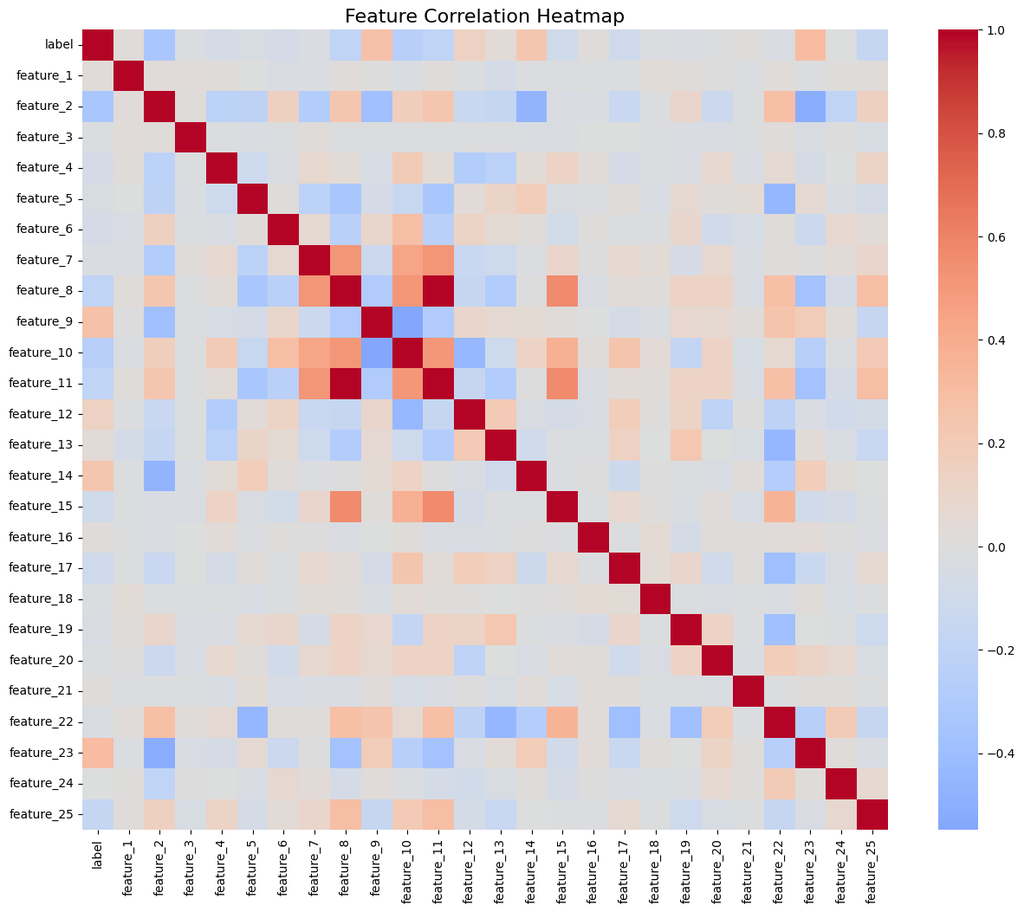

```python
# Correlation Analysis

import seaborn as sns
import matplotlib.pyplot as plt

# Join features and labels into one DataFrame for full analysis
df_corr = train_df.drop(columns=["Unnamed: 0"])  # Drop index column

# Compute correlation matrix
corr_matrix = df_corr.corr()

# Plot heatmap
plt.figure(figsize=(15, 12))
sns.heatmap(corr_matrix, annot=False, cmap='coolwarm', center=0)
plt.title("Feature Correlation Heatmap", fontsize=16)
plt.show()
```

```python
# Outlier Detection

from scipy.stats import zscore
import numpy as np

# Extract feature-only data
X_features = train_df[feature_cols]

# Compute z-scores for all features
z_scores = np.abs(zscore(X_features))

# Set a threshold (e.g., z > 3 = outlier)
threshold = 3
outlier_mask = (z_scores > threshold).any(axis=1)

# Number and sample of outliers
print(f"Number of rows with at least one outlier: {np.sum(outlier_mask)}")
print("Example outlier rows:")
print(train_df[outlier_mask].head())
```

```
Number of rows with at least one outlier: 87
Example outlier rows:
    Unnamed: 0  label  feature_1  feature_2  feature_3  feature_4  feature_5  \
8            8      3  -0.233307  -2.329114   1.356294  -3.366079  -0.313720
38          38      1  -0.852814   1.965649   1.002448   3.703523  -0.726227
66          66      2   0.925760  -1.833653  -1.411388  -1.148556   0.640109
86          86      2  -0.670716  -2.748784   0.853528  -1.575577  -0.126118
98          98      1  -1.316229   0.011223   0.346410  -0.083369   1.143359

    feature_6  feature_7  feature_8  ...  feature_16  feature_17  feature_18  \
8    1.094021   2.914398  -0.198748  ...   -0.297843    3.667236    0.401311
38   4.087732   5.414148   9.099873  ...   -0.638406   -5.696112    0.206345
66  -1.165058   0.623830  -0.381179  ...   -0.646179   -1.879241   -0.394360
86   5.080814   0.415892  -4.373617  ...    0.633443    6.361348   -1.366298
98   0.684313  -2.674070  -1.019587  ...    0.779754   -1.058609   -2.747877

    feature_19  feature_20  feature_21  feature_22  feature_23  feature_24  \
8     3.256042   -1.844978   -0.830582  -11.632640    1.770667    0.918352
38   -1.543340    3.830369   -0.714907   21.915341   -3.576898    6.397457
66    1.394812    1.318793    3.983165    3.240576    0.881141   -0.057879
86    3.671686   -2.690031   -0.662632  -23.534151    4.670952   -1.371077
98   -0.367958   -1.378149   -0.840171   -4.597648   -1.177956  -10.604565

    feature_25
8     0.092000
38    1.822722
66   -2.893265
86    1.835386
98   -0.424242

[5 rows x 27 columns]
```

# Conclusion

In this project, we conducted a comparative analysis of two machine learning algorithms — K-Nearest Neighbors (KNN) and Linear Support Vector Classifier (LinearSVC) — on a dataset consisting of 1300 samples, each with 25 numerical features and a corresponding label drawn from five possible classes. A separate test set, also consisting of 1300 unlabeled samples with the same feature structure, was provided for final prediction. The goal was to preprocess the data, tune each model appropriately, assess their performance, and ultimately choose the best-performing model for generating predictions on the test data.

The analysis began with loading and inspecting the training and test datasets. The training data contained an extra column (Unnamed: 0) used as an index and a label column for supervised learning. The test set contained an id column that was later dropped during preprocessing. Upon confirming that all 25 features were numerical and that there were no missing values, we proceeded to data preparation. We dropped the irrelevant index and ID columns and then applied standardization using StandardScaler to bring all features to the same scale — a crucial step for algorithms such as KNN and SVM which are sensitive to feature magnitudes.

Next, we split the training data into a training subset (80%) and a validation subset (20%) using stratified sampling to ensure class distributions were preserved. This setup allowed us to perform robust model evaluation without relying on the test set, which was strictly reserved for final predictions. Using GridSearchCV, we then tuned the hyperparameters for both algorithms. For KNN, we explored a range of values for n_neighbors from 1 to 20, as well as two weighting schemes: 'uniform' and 'distance'. The best performance was achieved with n_neighbors=18 and weights='distance', giving a cross-validation accuracy of approximately 70.9%. For LinearSVC, we experimented with different regularization strengths (C) and found that C=0.001 gave the best results, though with a lower cross-validation accuracy of around 55.9%.

We then evaluated both models on the validation set. KNN achieved a validation accuracy of 66.9%, showing strong precision and recall across most classes, particularly class 0 (precision = 0.84) and class 2 (recall = 0.73). In contrast, LinearSVC reached only 55% accuracy and showed weaker performance overall, particularly on classes 0 and 3. Given the superior performance of KNN in both cross-validation and validation evaluation, we selected it as the final model.

The chosen KNN model was retrained on the entire training dataset to maximize learning from the full sample size. We then used this final model to predict labels for the 1300 test samples. The output predictions were displayed directly in the notebook and were also saved in a format suitable for submission if required — a plain .txt file containing one predicted label per line, with no header or index. The first several predictions included values such as [3, 2, 4, 2, 1, 3, 4, 1, 4, 4, ...], consistent with the expected label structure of the task.

Through systematic preprocessing, parameter tuning, evaluation, and interpretation, we concluded that KNN with n_neighbors=18 and distance-based weighting was the most suitable algorithm for this classification task. It consistently outperformed LinearSVC and produced reliable predictions. This process illustrates the importance of comparative modeling, evidence-based selection, and principled machine learning practices in real-world data science workflows.